# randon forest

- *Bootstraping:* é uma técnica de amostragem nas observações, mas com reposição. Para cada amostragem cria-se um modelo.
- *Aggregation:* Agregação de vários modelos. Podemos pegar o valor de uma métrica em particular e avalia-la em todos modelos encontrados com Bootstraping. Podemos olhar o valor da métrica mais frequente (hard voting).

A junção de Bootstraping e Aggregation geram aleatoriedade. Bootstraping + Aggregation = Bagging

Random Forest: é um tipo de bagging que usa modelos de árvores de decisão, mas que acrescenta aleatoriedade nas escolha de variáveis preditoras em cada modelo gerado. Se y for contínua será escolhida 1/3 das variáves preditoras de forma aleatória em cada modelo, se y for categória será escolhido raiz quadrada da quantidade de variáves preditoras de forma aleatória em cada modelo.

Exemplo de random forest (bagging) com resposta binária:

```r
data = read.csv("data/titanic.csv")

data$Survived = as.factor(data$Survived)
data$Survived = relevel(data$Survived, ref="N")

data$Pclass = as.factor(data$Pclass)
data$Sex = as.factor(data$Sex)
data$Embarked = as.factor(data$Embarked)
```

80% de 1´s e 20% de 2´s para separar as amostras. A probabilidade de ser 1 é 80%, de ser 2 é 20%:

```r
set.seed(123)
n <- sample(1:2,size=nrow(data),replace=TRUE,prob=c(0.8,0.2))
treino <- data[n==1,]
teste <- data[n==2,]
```

random forest:

```r
library(randomForest)
modelo_rf <- randomForest::randomForest(
  Survived ~ .,
  data = treino,
  ntree = 50,
  mtry = 3,
  importance = T)
```

Predição na base de treino:

```r
p_treino <- predict(modelo_rf, treino, type='prob') # Probabilidade predita
c_treino <- predict(modelo_rf, treino)              # Classificação
```

Predição na base de teste:

```r
p_teste <- predict(modelo_rf, teste, type='prob')
c_teste <- predict(modelo_rf, teste)
```

Dataframe na base de treino:

```r
aval_treino <- data.frame(obs=treino$Survived,
                             pred=c_treino,
                             Y = p_treino[,2],
                             N = 1-p_treino[,2])
```

Data frame na base de Teste

```r
aval_teste <- data.frame(obs=teste$Survived,
                            pred=c_teste,
                            Y = p_teste[,2],
                            N = 1-p_teste[,2])
```

Valor ROC base de treino:

```r
tcs_treino <- caret::twoClassSummary(aval_treino, lev=levels(aval_treino$obs))
tcs_treino
```

```
##       ROC      Sens      Spec
## 0.9836281 0.9772727 0.8763636
```

Valor ROC base de teste:

```r
tcs_teste <- caret::twoClassSummary(aval_teste,lev=levels(aval_teste$obs))
tcs_teste
```

```
##       ROC      Sens      Spec
## 0.9038751 0.9357798 0.6716418
```

Curva ROC

```r
library(tidyverse)
library(memisc)
```

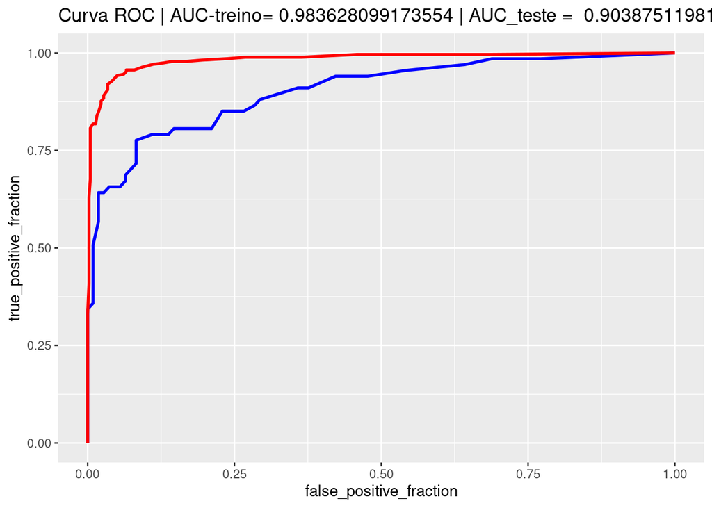

```r
ggplot2::ggplot(aval_teste, aes(d = obs, m = Y, colour='1')) +
  plotROC::geom_roc(n.cuts = 0, color="blue") +
  plotROC::geom_roc(data=aval_treino,
                  aes(d = obs, m = Y, colour='1'),
                  n.cuts = 0, color = "red") +
  scale_color_viridis_d(direction = -1, begin=0, end=.25) +
  theme(legend.position = "none") +
  ggtitle(paste("Curva ROC | AUC-treino=",
              tcs_treino[1],
              "| AUC_teste = ",
               tcs_teste[1]))
```

# grid search + k-fold

```r
library(caret)
controle <- caret::trainControl(
  method='repeatedcv', # Solicita um K-Fold com repetições
  number=4, # Número de FOLDS (o k do k-fold)
  repeats=2, # Número de repetições
  search='grid', # especifica o grid-search
  summaryFunction = twoClassSummary, # Função de avaliação de performance
  classProbs = TRUE) # Necessário para calcular a curva ROC
```

```r
grid <- base::expand.grid(.mtry=c(1:10))
```

Treinar todos os modelos do grid-search com cross-validation:

```r
gridsearch_rf <- caret::train(Survived ~ .,         # Fórmula (todas as variáveis)
                              data = treino,       # Base de dados
                              method = 'rf',        # Random-forest
                              metric='ROC',         # Escolhe o melhor por essa métrica
                              trControl = controle, # Parâmetros de controle do algoritmo
                              ntree=100,            # Numero de árvores
                              tuneGrid = grid)      # Percorre o grid especificado aqui
```

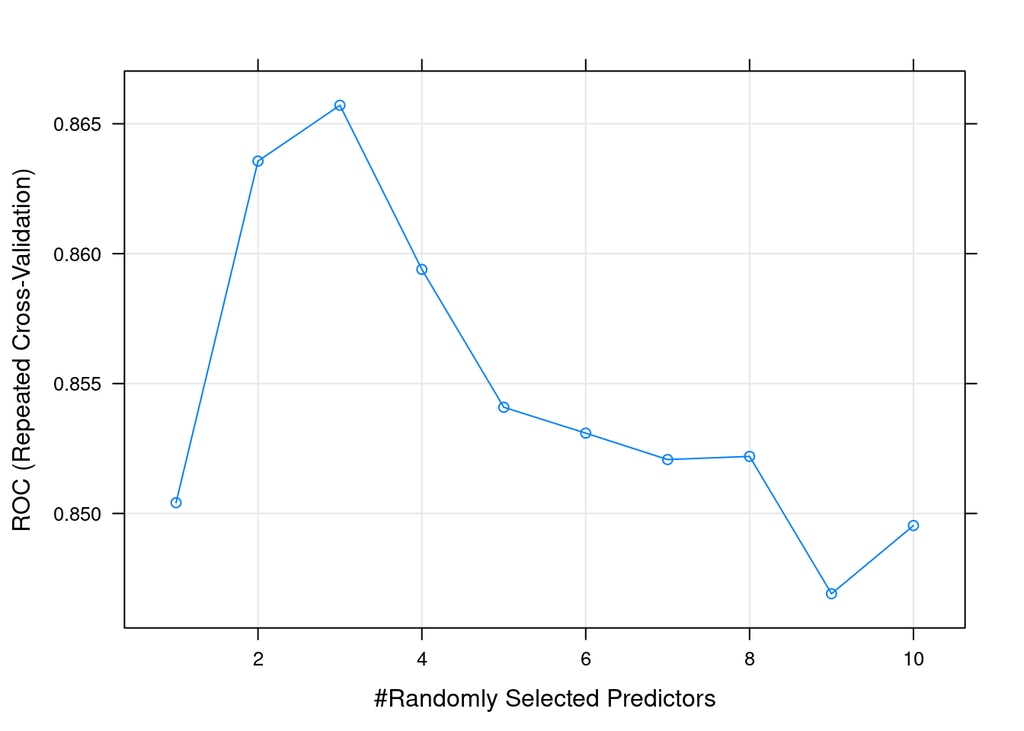

```r
plot(gridsearch_rf)
```

```r
print(gridsearch_rf)
```

```
## Random Forest
##
## 715 samples
##   7 predictor
##   2 classes: 'N', 'Y'
##
## No pre-processing
## Resampling: Cross-Validated (4 fold, repeated 2 times)
## Summary of sample sizes: 537, 536, 536, 536, 536, 537, ...
## Resampling results across tuning parameters:
##
##   mtry  ROC        Sens       Spec
##    1    0.8504135  0.9465909  0.5559197
##    2    0.8635623  0.9215909  0.6489237
##    3    0.8657107  0.9090909  0.6961850
##    4    0.8593934  0.8909091  0.7216272
##    5    0.8540869  0.8784091  0.7161658
##    6    0.8530921  0.8693182  0.7071078
##    7    0.8520752  0.8693182  0.7052696
##    8    0.8521967  0.8636364  0.7088928
##    9    0.8469108  0.8636364  0.7071345
##   10    0.8495346  0.8590909  0.7016198
##
## ROC was used to select the optimal model using the largest value.
## The final value used for the model was mtry = 3.
```

Predição na base de treino:

```r
p_treino <- predict(gridsearch_rf, treino, type='prob') # Probabilidade predita
c_treino <- predict(gridsearch_rf, treino)              # Classificação
```

Predição na base de teste:

```r
p_teste <- predict(gridsearch_rf, teste, type='prob')
c_teste <- predict(gridsearch_rf, teste)
```

Dataframe na base de treino:

```r
aval_treino <- data.frame(obs=treino$Survived,
                             pred=c_treino,
                             Y = p_treino[,2],
                             N = 1-p_treino[,2])
```

Data frame na base de Teste

```r
aval_teste <- data.frame(obs=teste$Survived,
                            pred=c_teste,
                            Y = p_teste[,2],
                            N = 1-p_teste[,2])
```

Valor ROC base de treino:

```r
tcs_treino <- caret::twoClassSummary(aval_treino, lev=levels(aval_treino$obs))
tcs_treino
```

```
##       ROC      Sens      Spec
## 0.9705744 0.9750000 0.8181818
```

Valor ROC base de teste:

```r
tcs_teste <- caret::twoClassSummary(aval_teste,lev=levels(aval_teste$obs))
tcs_teste
```

```
##       ROC      Sens      Spec
## 0.9039436 0.9724771 0.6865672
```

Curva ROC

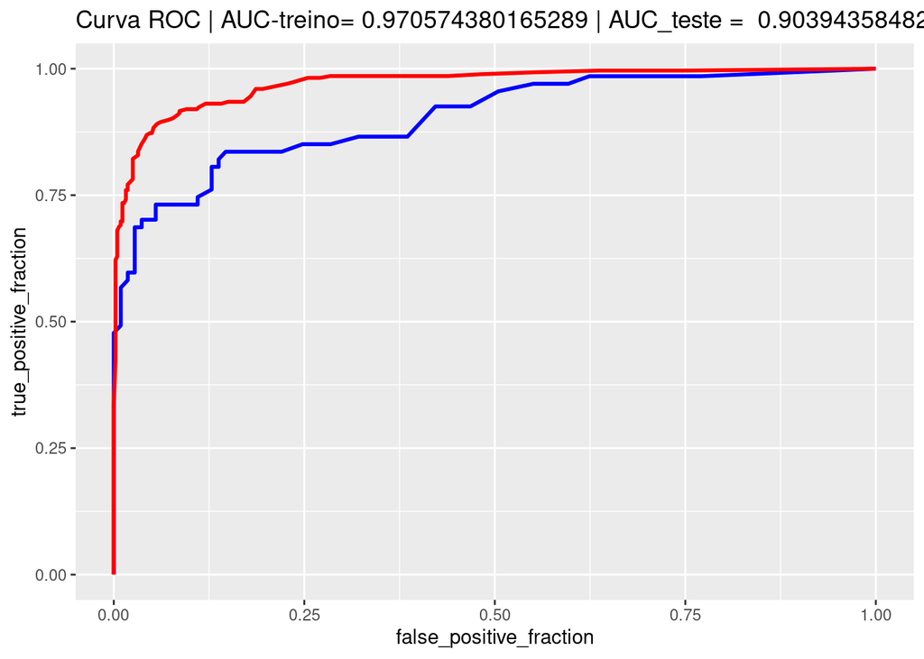

```r
library(tidyverse)
library(memisc)


ggplot2::ggplot(aval_teste, aes(d = obs, m = Y, colour='1')) +
  plotROC::geom_roc(n.cuts = 0, color="blue") +
  plotROC::geom_roc(data=aval_treino,
                  aes(d = obs, m = Y, colour='1'),
                  n.cuts = 0, color = "red") +
  scale_color_viridis_d(direction = -1, begin=0, end=.25) +
  theme(legend.position = "none") +
  ggtitle(paste("Curva ROC | AUC-treino=",
              tcs_treino[1],
              "| AUC_teste = ",
               tcs_teste[1]))
```